# Assignment4

```r
library(tidyverse)
library(smmr)
```

## a) Read in and display (some of) the data.

```r
url <- "http://ritsokiguess.site/datafiles/binge-eating.csv"
binge_eating <- read_csv(url)
head(binge_eating)
```

| treatment | episodes |
| --- | --- |
| cbt-wlt | 23 |
| cbt-wlt | 0 |
| cbt-wlt | 2 |
| cbt-wlt | 1 |
| cbt-wlt | 0 |
| cbt-wlt | 4 |

## b) Make a suitable graph. What does your graph suggest about the relative effectiveness of the three treatments?

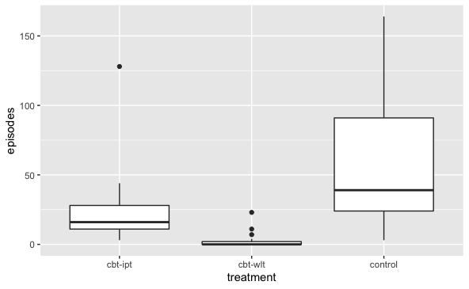

```r
binge_eating %>%
  ggplot(aes(x = treatment, y = episodes)) + geom_boxplot()
```

The lower the number of episodes, the better the effect of the treatment. Therefore, WLT treatment is the most effective, IBT group is the second effective, and the control group is the least effective.

## c) Why would a Mood’s median test be the preferred method of analysis here? Explain briefly. (There are two ideas to talk about.)

Compared to the ANOVA test, Mood’s median test is usually used if the data don’t satisfy 2 assumptions: One is the populations all follow the normal distribution and the other is that every groups should have the same variance.

We can looked from the boxplots of the data that WIT group’s data don’t follow the normal distribution. And the variances of each group is not same, the variances of the control group is larger than the two CBT groups.

So we cannot use ANOVA test, and we alternatively use the Mood’s median test.

## d) Run Mood’s median test. What do you conclude, in the context of the data?

```r
median_test(d=binge_eating, x=episodes, g=treatment)
```

```
$table
         above
group     above below
  cbt-ipt     9     3
  cbt-wlt     1    15
  control     9     1

$test
```

| what | value |
| --- | --- |
| statistic | 2.165000e+01 |
| df | 2.000000e+00 |
| P-value | 1.989584e-05 |

```
NA
```

H0: median wlt = median ipt = median control Ha: the medians of 3 groups are not equal The p-value < 0.05, so we reject H0, we conclude that the medians of 3 groups are not all equal.

## e) If appropriate, run any follow-up tests suggested by your Mood’s median test. What do you conclude about the relative effectiveness of the three treatments? In particular, what would you say about the effectiveness of the interpersonal therapy?

```r
pairwise_median_test(binge_eating,x=episodes, g = treatment)
```

| g1 | g2 | p_value | adj_p_value |
| --- | --- | --- | --- |
| cbt-ipt | cbt-wlt | 5.060422e-05 | 0.0001518127 |
| cbt-ipt | control | 4.052413e-02 | 0.1215723849 |
| cbt-wlt | control | 4.966125e-04 | 0.0014898374 |

Both adj-pvalue of “cbt-ipt vs cbt-wlt” and “cbt-wlt vs control” < 0.05. So there are obviously difference between “wlt and ipt”, “wlt and control”. Therefore, we can conclude that WLT treatment has significantly difference for other two treatment.

The adj-pvalue of “IPT vs Control” > 0.05, so it does not have significantly difference between this two treatment.We cannot conclude that interpersonal therapy is an effective treatment for binge-eating.